# Workshop 2 - Code Repositories and Regular Expressions

Joseph Williamson

2022

## A Workshop of Two Halves

In the first half we will be setting up our code repositories in GitHub, before learning about searching through text-based data using regular expressions in the second half.

## 1. Git and GitHub

By now you should hopefully have some idea about what Git and GitHub are, and why we might be keen to use them as data scientists. You should also have already created your own GitHub account. We now need to connect that *GitHub account* to the *BIO319 GitHub Classroom*, and then connect that to our *Posit Cloud* account.

### 1.1. GitHub Classroom

First, click on the following link to join our new GitHub classroom - [GitHub Classroom Invite](https://classroom.github.com/a/4A46HeNQ).

Find your name on the list to link your GitHub account to.

You will then be prompted to accept the assignment which will create a repository of all the files you need for today’s workshop (you may need to refresh the page after a few seconds for the repository to finish being created).

Click on the created hyperlink to be directed to your shiny new repo in the [‘Queen-Mary-University-London-BIO319’](https://github.com/Queen-Mary-University-London-BIO319) organisation page. **Copy the link to your new repository** so that we can connect it to Posit Cloud.

### 1.2. Connecting Posit Cloud

You must now go and click on your profile in the top right of Posit Cloud and go to authentication.

[figure not shown]

*Location of the authentication button in Posit Cloud*

Next, **enable GitHub** and **enable private repo access**. You will be prompted by GitHub whether you want to **authorise RStudio two times** - once for each of the check boxes.

[figure not shown]

*How to enable GitHub in Posit Cloud*

Navigate your way back to the Posit Cloud ‘BIO319 2023 Workspace’ and click the ‘New Project’ drop down list in the top right, selecting ‘New Project from Git Repository’.

[figure not shown]

*Button to select new project based off a Git repository*

Paste in the Git repository that you copied earlier and hit ‘OK’. If you no longer have the repository, go to the [‘Queen-Mary-University-London-BIO319’](https://github.com/Queen-Mary-University-London-BIO319) organisation page to find your new repository again.

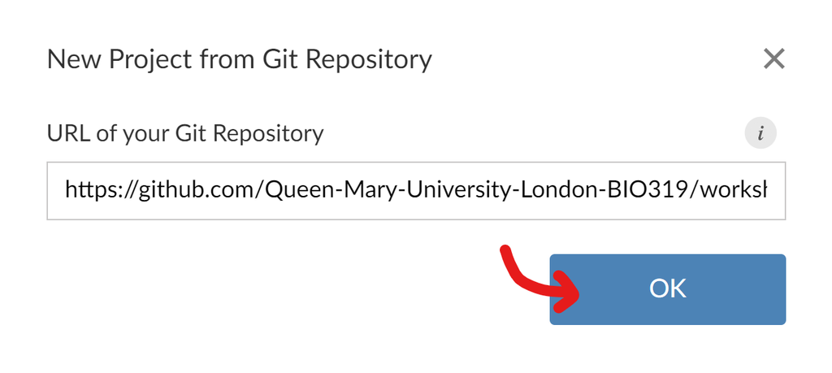

*Insert your Git repository in the box and hit OK*

This should have set you up in a new project with all the files you will need for the rest of today’s workshop. Try opening up ‘Workshop2.html’ from the files pane to find the rest of your instructions for today’s session!

### 1.3. Personal Access Token

The final bit of admin you will need to do to complete your integration of Posit Cloud and GitHub is to create a personal access token (PAT). This is used in place of a password to securely link third party applications (like Posit Cloud) to GitHub. You will need these to *push* your updates to your repository after you have finished editing your files.

A PAT can be generated by clicking on your profile picture in the top right of the GitHub homepage and selecting settings, and then going to ‘Developer settings’ at the bottom of the toolbar on the left.

[figure not shown]

*Press the settings button in the drop down section of your profile*

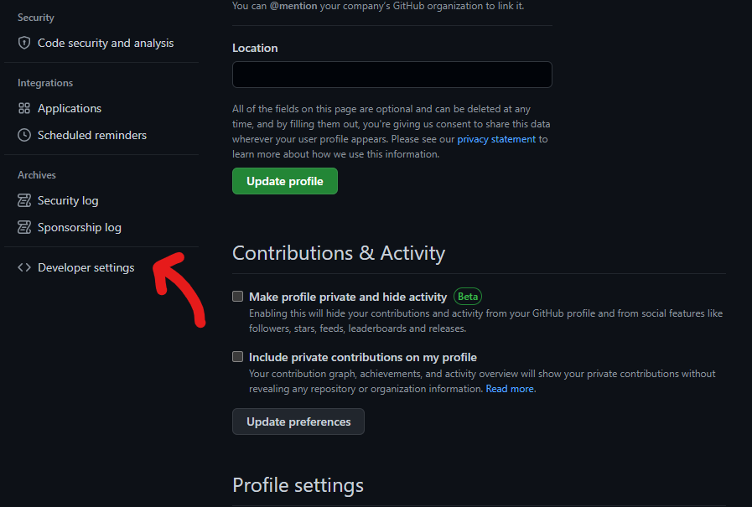

*Go to the Developer settings tab in the settings page*

Go on the ‘Personal access tokens’ tab and press the generate new tokens button on the right hand side of the page.

[figure not shown]

*Click ‘Personal access tokens’ and ’Generate new token*

In the note box write ‘My First PAT’, set the expiration to 90 days and click the ‘repo’ box, before hitting the green ‘Generate token’ button at the bottom of the page.

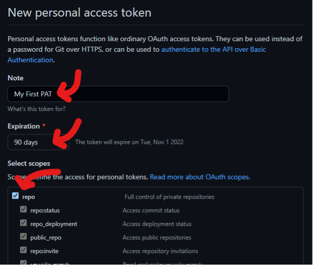

*Fill in the information from above for your PAT*

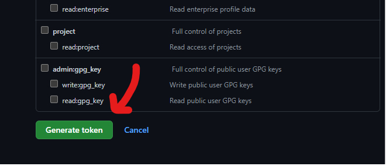

*Hit the green button to finish*

You will be given a string of letters and numbers (it should start with ‘ghp_’) and save it somewhere safe (not in your emails, best to save it in your onedrive folder somewhere).

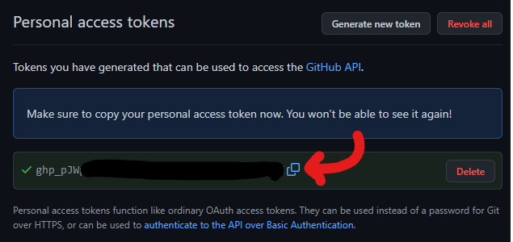

*Copy your new PAT somewhere safe!*

### 1.4. Learning to Commit

You have done all the arduous admin so that you can now get on with using Posit Cloud and GitHub in conjunction. Well done!

Let’s navigate back to your Posit Cloud project that you created from your shiny new Git repository. You should now be able to see the files that have been downloaded into your project from your Git repository in the ‘Files’ pane in the bottom right.

You should also be able to see a ‘Git’ tab in the top right. Click on this to see if your files are synced with your Git repository. When you first click this, you will see two files called ‘.gitignore’ and ‘project.Rproj’. The first is automatically created by git when you first **pull** the repository. Remember ‘pulling’ a repository just means creating a local copy and your computer (or in this case in Posit Cloud), that you can work on. Similarly the ‘project.Rproj’ file is created by Posit Cloud every time you create a new project.

Let’s open up the RScript ‘HelloWorld.R’ to practice using Git. On opening you will see that this is a very simple file that prints the words `'Hello World!'` when run.

Try updating the script to also print the words `'I am a sentient machine'`. Save your new file. You should see that ‘HelloWorld.R’ has appeared in your Git tab in the top right corner with a blue ‘M’ beside it. Click the ‘Staged’ box and then press the ‘Commit’ button.

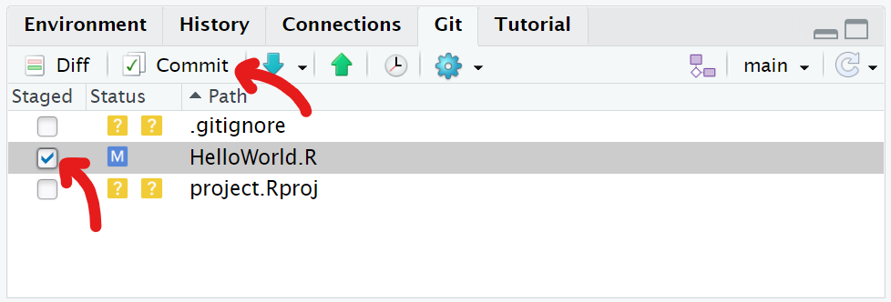

*Use the Git tab in the topright corner to commit your changes*

After you hit the ‘Commit’ button, a new window will pop up. If the ‘Ignore Whitespace’ box is not checked, be sure to check it before proceeding. You will now be able to see the edits you have made to the script at the bottom of the screen.

Insertions are highlighted in green and deletions are in red. As we have only inserted some new code, we will just see our new lines highlighted in green. We need to add a commit message in the top-right box that gives a useful description of the edits you have made to the file. In this instance we can say “add ‘I am a sentient machine’ to the print outputs”. Finally we can hit the ‘Commit’ button on the right hand side in order to commit our changes to Git, and close the pop-up window.

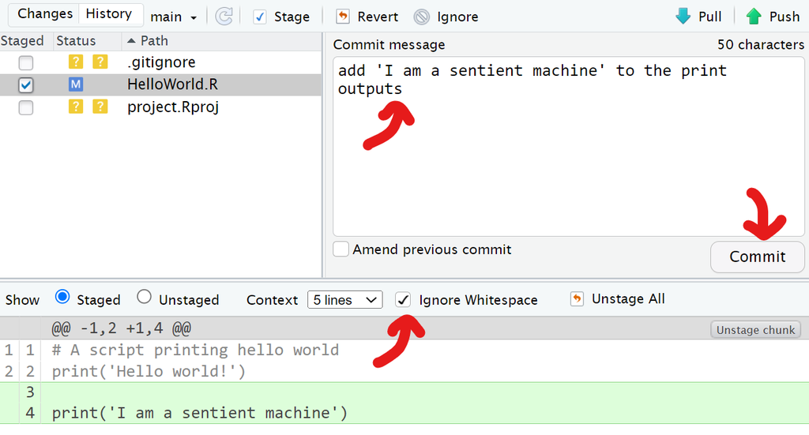

*Enter a useful description of the changes you have made to the file(s)*

Congratulations! You have made your first commit. Your fear of commitment is vanquished!

Remember that this does not mean your GitHub repository has updated, you have just got those edits ready to send to the repository and have added a message describing what you did.

Let’s edit the script again so that we can make another *commit*, before we *push* our *commits* to the repository all at once. Try adding another line of code that asks whether **1 is less than 2 AND whether 3 is greater than or equal to 3**. Then delete the first line where we have described the file and update it to be more accurate. Once you are happy with your changes, make your second commit, with a different message this time describing these new edits.

Once you have made your commits it is time to *push* all your commits to your repository. In our Git pane it now says that “Your branch is ahead of ‘origin/main’ by 2 commits.” as we are 2 commits ahead of our repository.

Press the push button and enter your **GitHub username**, followed by the **Personal Access Token (PAT)** that we generated earlier in the session and you put somewhere super secure. Note that it asks for your password, but if you use this you will get an error message, so make sure to use that PAT!

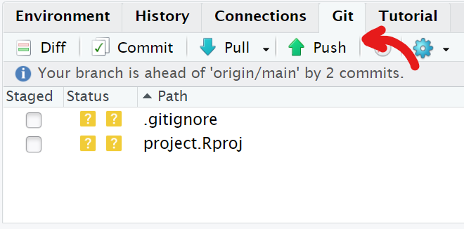

*Click the push button to update your repository with your new commits*

If you now head back to your GitHub repository in the [‘Queen-Mary-University-London-BIO319’ organisation page](https://github.com/Queen-Mary-University-London-BIO319) you can see that it now says there have been 3 commits (including the initial commit made by GitHub Classroom to create your repository for you). If you click on this you can see your commit history for the repository.

**Try having a closer look at some of these commits** by clicking on them, you will be able to see that GitHub has tracked what edits you made to the code. You can even leave comments on these commits to discuss them if you were working as part of a coding team!

[figure not shown]

*View the commit history of your whole repository by clicking on the commit link in the top right*

Equally, if you navigate back to the repository main page and click on an individual file (such as ‘HelloWorld.R’), followed by the history button in the top right, you can view the histories of specific files.

You might be starting to see just how powerful this version control tool might be when writing code, especially in a project with multiple people working on it. At any point you can go and look at what people have editted, and find older versions if you need to recover what the repository looked like at an earlier time!

If you still have some time left before the second half of the workshop, try going to the [‘GitHub-starter-course’ repository](https://github.com/Queen-Mary-University-London-BIO319/github-starter-course) located in the [‘Queen-Mary-University-London-BIO319’ organisation page](https://github.com/Queen-Mary-University-London-BIO319). This will help you become familiar with all these new terms such as *repository*, *push*, *pull*, *commit* and many more.

Additionally, you can **try making more edits and commits to your repository via Posit Cloud**. You can even **try making some new files, or uploading them from your computer**!

## 2. Regular Expressions

In data science sometimes we might want to search through our data to find certain information. To do so we can use a powerful and flexible tool called a regular expression. Regular expressions not only allow you to look for specific characters, words or phrases, but can also look for complex text patterns.

Before we get going, remember that we have provided you with a regular expression cheatsheet in the ‘Useful Resources’ section of the BIO319 QM+ homepage!

### 2.1. An Introduction

Let us consider the following vector containing a quote from *Ministry of Utmost Happiness* by Arundhati Roy in the from of a character vector:

```r
sentence <- c('By','the','time','they', 'got', 'back,', 'the', 'lights', 'were', 'all', 'out', 'and', 'everybody', 'was', 'asleep.', 'Everybody,', 'that', 'is,', 'except', 'for', 'Guih', 'Kyom', 'the', 'dung', 'beetle.', 'He', 'was', 'wide', 'awake', 'and', 'on', 'duty,', 'lying', 'on', 'his', 'back', 'with', 'his', 'legs', 'in', 'the', 'air', 'to', 'save', 'the', 'world', 'in', 'case', 'the', 'heavens', 'fell.')
```

If we decided we wanted to find out where the word `'the'` is in this vector, we could use a function from a family of regular expression functions. Lets start with the `grep()` function:

```r
grep_out <- grep(pattern = 'the', x = sentence)
grep_out
```

```
## [1]  2  4  7 23 41 45 49
```

First, look at the syntax of the function (the arrangement of words in our first line of code). We have defined two function arguments; `pattern` and `'x'`. The first is the pattern that we want to look for in our text, the second is the character vector to search through (our `sentence` object we created above).

`grep()` has returned us a numeric vector. If we look carefully at these numbers, we can see that they correspond to the position of every `the` in our `sentence` vector.

We can check this using the `grep_out` to subscript our `sentence` using square brackets. This will return all the words at the positions `grep()` gave us.

```r
sentence[grep_out]
```

```
## [1] "the"  "they" "the"  "the"  "the"  "the"  "the"
```

Note that `grep()` has also returned the position of `'they'`, as it contains `'the'`. If we wanted to avoid this, you can tell `grep()` that you want the match to start before the ‘t’ using the ^ symbol, and end after the ‘e’ using the $ symbol by changing the pattern argument to `pattern = '^the$'` (these special characters are called anchors).

**Start a new script called ‘RegularExpressions.R’, create the relevant variables using the code above and try using ^ and $ for yourself!**

**Try searching for other letters, words or word fragments using the grep() function.**

**You can copy the code in this worksheet by pressing the copy button in the corner.**

**Remember that you should be annotating your code AND committing new work to GitHub with adequate comments.**

### 2.2. Regular Expression Tools

Regular expressions can search much more flexibly than just looking for specific words. For example, we can search for the elements that contain a capital letter using the pattern `'[A-Z]'`.

```r
grep_out <- grep(pattern = '[A-Z]', x = sentence)
grep_out
```

```
## [1]  1 16 21 22 26
```

Alternatively we can look for lowercase letters using `'[a-z]'` or any letters regardless of case using `'[A-z]'`. Similarly we can search for numbers using `'[0-9]'`.

We can also use the special character `'.'` to specify that any character can match the search pattern. This may seem counter intuitive at first, why search for a character that will match to any other character? The power of the `'.'` comes into play when used *with* other characters. For example, if we search for `'a.e'` we are looking for matches where there is an `'a'` and an `'e'` separated by any character.

```r
grep_out <- grep(pattern = 'a.e', x = sentence)
sentence[grep_out]
```

```
## [1] "awake"   "save"    "case"    "heavens"
```

We can see in the above example that grep has found four elements of our vector that contain an `'a'` and an `'e'` separated by any character - aw**a**k**e**, s**a**v**e**, c**a**s**e** and he**a**v**e**ns.

**Try searching through the quote yourself using some of the flexible regular expression patterns outlined above.**

### 2.3. Quantifiers

A final important concept in regular expressions we are going to address today is the use of **quantifiers**. These allow the user to specify how many of a character (or set of characters) `grep()` is matching to. The three main symbols are ‘?’, ‘*’ and ‘+’.

‘?’ denotes 0 or 1 instances.

‘*’ denotes 0 or more instances.

‘+’ denotes 1 or more instances.

To show the difference between the three, consider the outputs of the following three lines of code:

```r
sentence[grep(pattern = 'e.?e', x = sentence)]
```

```
## [1] "were"      "everybody" "asleep."   "beetle."
```

```r
sentence[grep(pattern = 'e.*e', x = sentence)]
```

```
## [1] "were"      "everybody" "asleep."   "except"    "beetle."   "heavens"
```

```r
sentence[grep(pattern = 'e.+e', x = sentence)]
```

```
## [1] "were"      "everybody" "except"    "beetle."   "heavens"
```

**What is the difference between each line of code in the above example? How does this change what they are looking for? (Remember the full stop will match any character)**

### 2.4. The gsub() Function

In addition to the `'grep()'` function there are a whole host of other regular expression functions in R. For the purposes of today’s session, we would like to show you one more. The `'gsub()'` function can be used to search for text in the same way as the `'grep()'` function, but instead of finding the instances of our search term, it instead substitutes the matched text with text of our choosing.

Again using the Arundhati Roy quote, we can show what this actually means!

```r
gsub_out <- gsub(pattern = 'a.e', x = sentence, replacement = '!!!')
gsub_out
```

```
##  [1] "By"         "the"        "time"       "they"       "got"
##  [6] "back,"      "the"        "lights"     "were"       "all"
## [11] "out"        "and"        "everybody"  "was"        "asleep."
## [16] "Everybody," "that"       "is,"        "except"     "for"
## [21] "Guih"       "Kyom"       "the"        "dung"       "beetle."
## [26] "He"         "was"        "wide"       "aw!!!"      "and"
## [31] "on"         "duty,"      "lying"      "on"         "his"
## [36] "back"       "with"       "his"        "legs"       "in"
## [41] "the"        "air"        "to"         "s!!!"       "the"
## [46] "world"      "in"         "c!!!"       "the"        "he!!!ns"
## [51] "fell."
```

We can see that where `gsub()` has found matches to our pattern (`'a.e'`), it has replaced them with ‘!!!’. This is an incredibly useful tool for fixing errors in datasets, and is one we will use in the challenge below.

**Try writing your own line of code to replace all the letter ’t’s with question marks.**

### 2.5. The Challenge

Let’s use all the regular expression knowledge that you have picked up today to solve the following challenges in a new script called ‘RegularExpressionChallenge.R’.

Remember, as you write this script, you should be annotating it AND committing frequently to keep track of changes you make.

**1. Load in the ‘dung_beetles.csv’ into R**

**2. Have a look at the structure of the dataset. What sort of dataset do you think this is?**

**3. Make a new object that is a vector of all the species names so we can play around with it.** The colnames() function may come in useful here… so look it up in the R documentation or search online!

**4.Use your new found grep() prowess to find the names of all the species that have a genus name that starts with the letter ‘C’.**

**4. Find all the species where the specific epithet (the second word) starts with the letter ‘r’.**

**5. There is a typo in the species names! Replace all the ‘Copis’ genus names with the correct ‘Copris’ spelling.**

**6. Another genus name has been misspelled - ‘Microcopis’ should be ‘Microcopris’. Fix this too.**

**7. Make sure you have committed your last answers to Git. Now push all the commits you have made to your Git repository.**

**8. Now create a new gsub() command that replaces the one you used in question 5 and 6, so that it is flexible enough to fix both genus names in one go!** (Once you push these changes to GitHub again, you should be able to see the changes you are making over time in the repository history!)

**9. Replace the column names in your data set with your corrected ones.**

### 2.6. Optional Super Challenge!

**10. Find all the species where the genus starts with an ‘O’ and the specific epithet ends in an ‘s’.**

**11. Subset the dataframe using regular expressions so that it only contains data from months ending in a ‘y’ and genera starting with an ‘O’.**

### 2.7. The Final Push?

Hopefully, you have managed to get through a good chunk of the content set for you today. If you did not make - DO NOT WORRY! We covered a huge amount of new theory today.

Each week we will not set too much asynchronous prep, to give you plenty of time to catch up on any content you have slipped behind on.

For now, the last thing we need to do is that final commit (hopefully you have been doing these as you have been progressing), followed by that final push to your Git repository.